# TRIZ - A Very Contradictory Method

A Workflow for Students

Arvind V.

arvind.venkatadri@gmail.com

August 19, 2025

## Classical TRIZ

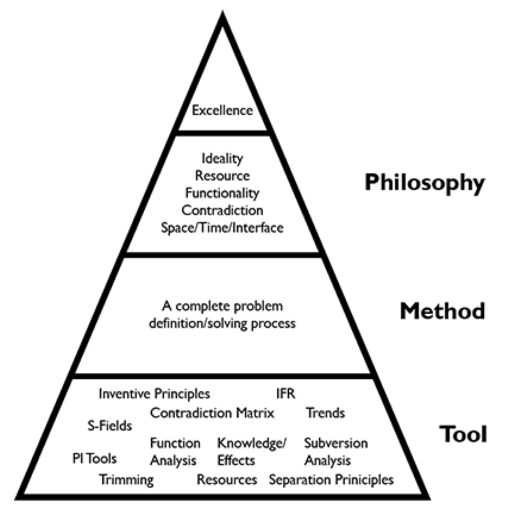

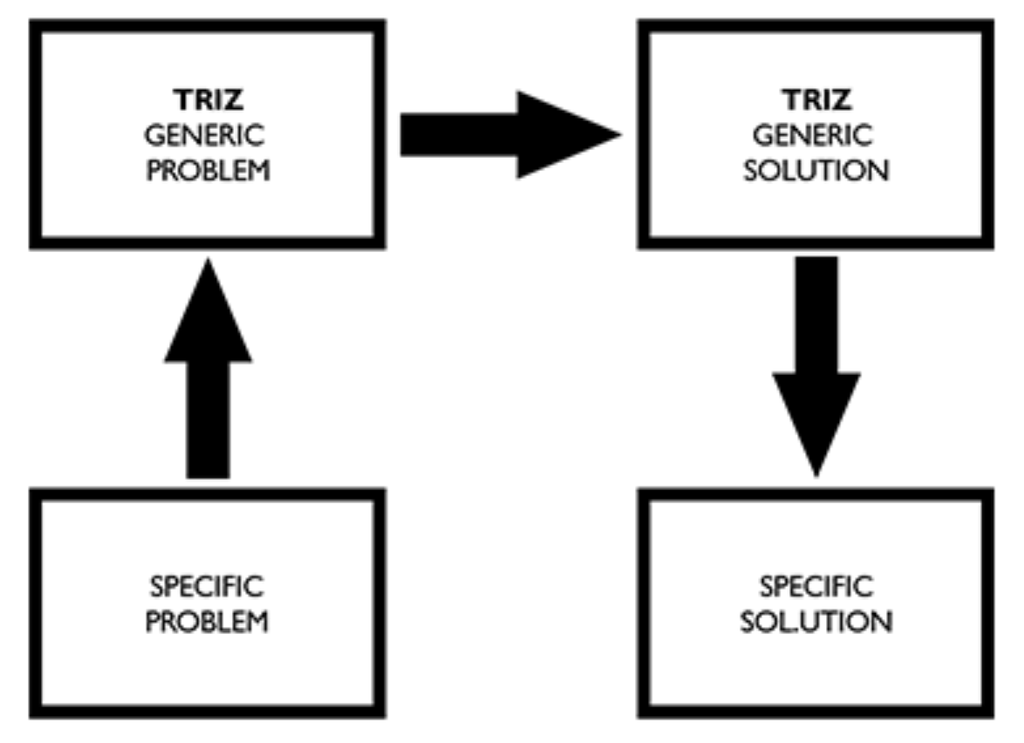

## A Well Known TRIZ example !!

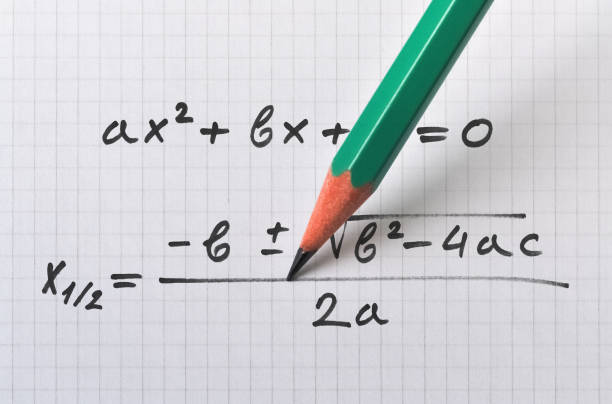

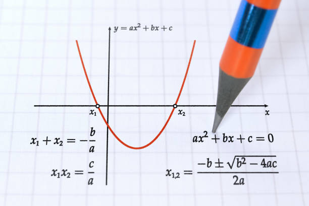

## A Generalized Solution

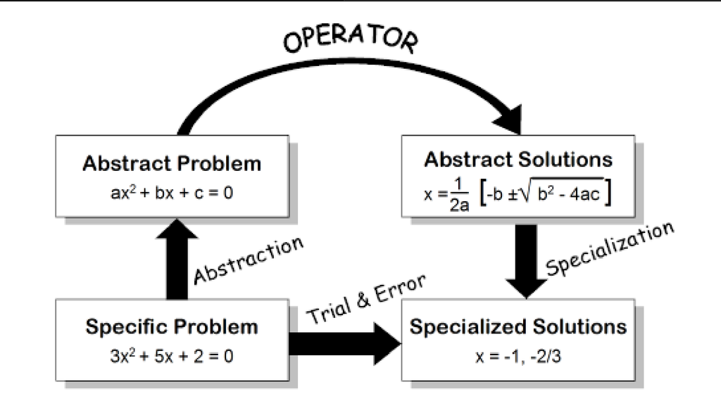

.footnote[Stan Kaplan, “An Introduction to TRIZ - The Russian System of Inventive Problem Solving”, Ideation International Inc]

## Even Quadratic Equations are Still Researched!!

[video not shown]

## TRIZ: A Quick Workflow

- Find a **PROBLEM**
- Formulate a **CONTRADICTION** (a trade-off or a compromise)
- Specify an **IDEAL FINAL RESULT**
- Convert/metaphorize the **CONTRADICTION** into **TRIZ PARAMETER**s
- Look up the **CONTRADICTION MATRIX**
- Discover the **INVENTIVE PRINCIPLES** you might apply
- *Un-metaphorize* the **INVENTIVE PRINCIPLES** to apply them in a specific way in your problem and solve it

Now let us look at these steps in pictorial detail 🖼

## TRIZ Workflow: Formulate a Problem Description

- Use your [**CULTURAL CAPITAL**](https://culturallearningalliance.org.uk/what-is-cultural-capital/) and your **DOMAINs** to write a PROBLEM in simple English
- Ask: **5W+H**
  - **What** does the problem seem to be?
  - **Who** has the problem?
  - **When** does the problem occur? All the time? Under certain circumstances?
  - **Where** does the problem occur?
  - **Why** does the problem occur?“Ask why 5 times” – W. Edwards Deming - **How** does the problem occur?
- Ellen Domb, [“How to help TRIZ Beginners Succeed”](https://www.metodolog.ru/triz-journal/archives/1997/04/a/index.html)
- Adobe Workfront Blog, [“The 5 Ws (and 1 H) that should be asked of every project!”](https://www.workfront.com/blog/project-management-101-the-5-ws-and-1-h-that-should-be-asked-of-every-project)
- [Cultural Learning Alliance: “What is Cultural Capital?”](https://culturallearningalliance.org.uk/what-is-cultural-capital/)
- [“Platform Creativity: Domain, Field, and Person”](https://medium.com/call4/domain-8a22b6b486f4)
- [Rudyard Kipling, “I Keep Six Honest Serving Men”](https://allpoetry.com/I-Keep-Six-Honest-Serving-Men)

## TRIZ Workflow: Look the “Resources” and Causes

To refine our Problem, what Resources do we have?

- One Good way to do this is using the **Ishikawa Diagram**
- Man, Material, Method, Management, Machinery (Ishikawa)
- This diagram is used **primarily** to assign **CAUSES**
- But it conveniently lists all the **Resources**.
- What things create the compromise/tradeoff?
- The Ishikawa Diagram is also called the **Fishbone Diagram** or **Cause-and-Effect Diagram**.

[figure not shown]

[Ishikawa Diagram](https://www.investopedia.com/terms/i/ishikawa-diagram.asp)

## TRIZ Workflow: Inspect the Ishikawa Diagram

- From the Ishikawa Diagram
  - What is **One Parameter or Knob** for each of the **Causes** that you have listed therein?
- Let us make a list for each Knob/Object:
  - What is the **Knob** meant to do? What is its main Purpose?
  - What are the other Accompanying Objects that it works with?
- What are the **current Settings** for each Knob?
- Change the Setting of Each Knob to its **natural opposite extreme**. What Happens?
  - You will see that in many cases, each Knob creates a Certain Outcome at one Setting and another Outcome at the Opposite Setting.
- This is the Source of your Administrative Contradiction !! ]  
  What sort of Contradictions do we see in these familiar objects? What is good and what is not so good? Could that be the source of a problem to solve?

## TRIZ Workflow: Example - Find a Problem

[figure not shown]

- I like Tea in the Mornings..and Afternoons and Evenings..and…
- Comes forth from your…**Cultural Capital** and **Domains**. Thanks to [Pierre Bourdieu](https://culturallearningalliance.org.uk/what-is-cultural-capital/) and [Mihaly Csikszentmihalyi](https://medium.com/call4/domain-8a22b6b486f4) for giving us those two Words!!
- Possible Problem Statements
  - Milk Boils Over
  - I am Bored Watching the Milk boil

## TRIZ Workflow: Example - Develop an AC

[figure not shown]

- Use the **Ishikawa Diagram** to Refine the AC
- Again use your **Cultural Capital** and **Domains**
  - *Watching the Milk is a Bore!!Can I do something else in the meantime?*
  - *But: the Milk will boil over…*
- **AC**:
  - **I can either boil Milk, OR do something else, NOT both.**

## TRIZ Workflow: Example - Refine the AC

[figure not shown]

- Use the Ishikawa Diagram:
- Man: Me?
- Method :
  - Operating the Stove
  - Wanting/Doing Two Things at the Same Time
- Material: Milk, Vessel, Stove, Gas, Time, Heat
  - Milk boils over when it is heated
- *Watching the Milk is a Bore!! Can I do something else in the meantime? But, the Milk will boil over…*

##TRIZ Workflow: Example - State the AC

.fancy.large.orange[I can operate the stove and save the Milk, but I will be bored and waste Time doing it**]

## TRIZ Workflow: Specify the Ideal Final Result (IFR)

- State an **Ideal Final Result**
- A basic principle of TRIZ is that systems evolve towards increased **ideality**, where ideality is defined as

$$Ideality = Benefits / (Harm + Costs)$$
- **Evolution** is in the direction of - ⬆ Increasing benefits - ⬇ Decreasing costs - ⬇ Decreasing harm - IFR allows us to **invert the direction of the problem**: to come backwards from Solution towards the Situation

The *extreme result* of this evolution is the Ideal Final Result: - It has all the benefits,  
- none of the harm, and - none of the costs of the original problem. - The Ideal Final Result describes the solution to a technical problem, **independent of the mechanism or constraints of the original problem**. - It occupies no space, has no weight, requires no labour, requires no maintenance.

## TRIZ Workflow: Example - State the IFR

.fancy.large.blue[IFR: The Milk must “boil itself” and wait for me without overflowing.]

Any other *even more unreasonable* way of saying this?

## TRIZ Workflow: Example - State the TC(s)

There can be more than one TC that you can set up !!

- TC #1: Improve **21-Stability** of Milk - without worsening **17-Energy Usage by Stationary Object**
- TC #2: Improve **25-Loss of Substance** of Milk - without worsening **26-Loss of Time**

## TRIZ Workflow: Example - State the TC

.fancy.large.orange[AC: I can operate the stove and save the Milk, but I will be bored and waste Time doing it.]

.fancy.large.blue[IFR: The Milk must “boil itself” and wait for me.]

.fancy.large.red[ - TC #1: 21-Stability of Milk without worsening 17-Energy Usage by Stationary Object - TC #2: Improve 25-Loss of Substance of Milk without worsening 26-Loss of Time]

## TRIZ Workflow: Use the Contradiction Matrix

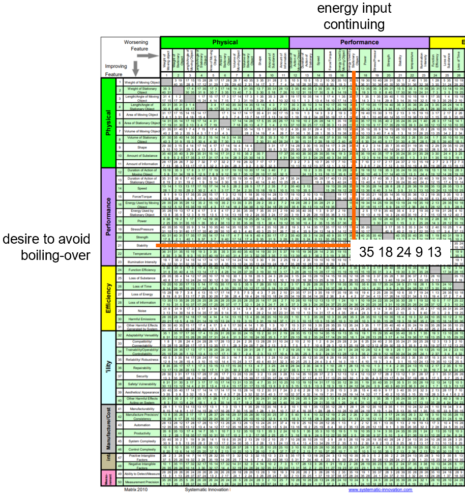

## TRIZ Workflow: IP-24: **INTERMEDIARY**

[figure not shown]

[figure not shown]

Also we can use two vessels, one inside the other. The inner one with milk and the other one with water!

## TRIZ Workflow: IP-18: **Mechanical Vibration**

[figure not shown]

A Milk Watcher

**A Milk Watcher Device** - This is dropped into the vessel before pouring the milk - It vibrates when the milk is boiling and prevents spillage - And of course, there is a patent. Yes , in Russia, where else !!

[Milk Saver Patent Web Page!!](https://findpatent.ru/patent/1/10362.html)

## TRIZ Workflow: IP-35: Parameter Change

- What “Parameter” can we change?
  - Temperature?
  - Rate of Gas?
  - Kind of metal used in Vessel?
  - Smoothness of the Vessel finish?

Here are some solutions using Parameter Change - Sprinkle Water on the Froth…Umm

- **Apply butter to the rim of the vessel beforehand !!**
- This is also a solution derivable from **IP-9: Prior Counter Action**

.footnote[https://www.herzindagi.com/recipe-tips/how-to-prevent-milk-from-boiling-over-article-161289#]

## TRIZ Workflow: IP - 13: The Other Way Around

What do you think?

- Cold Milk poured into an already hot vessel? Wild…
- How about the Two Vessel Trick, from earlier: one inside the other. The inner one with milk and the other one with water! Can the Water be hot before hand?
- Not all IPs may strike you as applicable!
- Try and leverage somebody’s else’s **Cultural Capital** !!

## Thanks!

[figure not shown]

Maurice Leloir (1851-1940)

#### Slides made

###### with

##### <i class="fab fa-r-project faa-vertical animated "></i>